# Презентация по теме “Игра полковника Блотто”

Математическое моделирование

Арбатова Варвара Петровна

1132236020@rudn.ru

Российский университет дружбы народов

2026-05-11

# Игра полковника Блотто

## Расстановка войск

- Поле сражения состоит из **5 боевых позиций**
- У Блотто — **100 танков**, у противника — **100 танков**
- Игроки **независимо** расставляют войска по позициям
- На каждой позиции побеждает тот, у кого **больше танков**
- В сражении побеждает тот, кто выиграл **больше позиций**

**Вопрос:** Как полковнику Блотто расставлять войска?

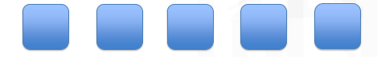

Рисунок 1: Схема поля боя

## Правила игры

- **2 игрока:** A и B
- Игрок A имеет $X_A$ единиц ресурса, игрок B — $X_B$ единиц
- Можно использовать **нецелое** число ресурса на поле
- **n полей**
- **Тай-брейкер:** если ресурсы равны —
  - либо побеждает игрок B
  - либо очки делятся пополам
  - в широком диапазоне параметров правило не играет роли

## Можно ли гарантировать победу?

Можно ли гарантировать победу?

**Нет** — противники одинаковы, оба не могут гарантировать победу.

Всегда можно отклониться в симметричную расстановку.

## Можно ли гарантировать ничью?

Можно ли гарантировать ничью?

Если да — значит, существует расстановка, которую невозможно обыграть.

## Пример расстановки

**Вопрос:** Как обыграть такую расстановку?

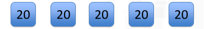

Рисунок 2: Расстановка

## Обыгрываем расстановку

| Стратегия Блотто | Противник подстраивается |
| --- | --- |
| 20 20 20 20 20 | 21 21 18 20 20 |

**Вывод:** Легко!

Точно так же можно обыграть **любую** другую расстановку.

# Нет равновесия в чистых стратегиях

## Шпионы в рядах

Если у каждой армии есть шпионы и они узнали планы соперника —  
**хотя бы одна сторона захочет изменить расстановку**.

**Утверждение.** При $n \ge 3$ в игре полковника Блотто **нет равновесия Нэша в чистых стратегиях**.

**Замечание.** При $n = 2$ и правиле «равенство — победа B» равновесий тоже нет.

# Смешанные стратегии

## Что такое смешанная стратегия?

Что такое смешанная стратегия?

- **n-мерная плотность распределения:**
  $$P : \mathbb{R}_+ \to [0,1]$$
- **Одномерные функции распределения:**
  $$F_j(x), \; j = 1, \dots, n$$
  — по одной функции на каждое поле

# Равновесие

## Случай 1

**Случай 1:** $\frac{2}{n} \le \frac{X_A}{X_B} \le 1, \quad n \ge 3$

**Функции распределения:**

$$F_A^j(x) = 1 - \frac{X_A}{X_B} + \frac{X_A}{X_B} \cdot \frac{nx}{2X_B}, \quad x \in \left[0, \frac{2X_B}{n}\right]$$

$$F_B^j(x) = \frac{nx}{2X_B}, \quad x \in \left[0, \frac{2X_B}{n}\right]$$

**Ожидаемые платежи:**

$$U_A = \frac{X_A}{2X_B}, \qquad U_B = 1 - \frac{X_A}{2X_B}$$

## Случай 2

**Случай 2:** $\frac{1}{n-1} \le \frac{X_A}{X_B} \le \frac{2}{n}, \quad n \ge 3$

**Функции распределения:**

$$F_A^j(x) = 1 - \frac{2}{n} + \frac{2x}{nX_A}, \quad x \in [0, X_A]$$

$$F_B^j(x) = \begin{cases} \dfrac{2x}{X_A} \left(1 - \dfrac{X_B}{nX_A}\right), & x \in [0, X_A] \\ 1, & x \ge X_A \end{cases}$$

**Ожидаемые платежи:**

$$U_A = \frac{2}{n} - \frac{2X_B}{n^2 X_A}, \qquad U_B = 1 - \frac{2}{n} + \frac{2X_B}{n^2 X_A}$$

## Случай 3

**Случай 3:** $\frac{1}{n} \le \frac{X_A}{X_B} \le \frac{1}{n-1}, \quad n \ge 3$

**Стратегия игрока A:**

- На $n-2$ случайных полей — **0 единиц**
- На оставшиеся 2 поля — случайная величина с **k равновероятными значениями**

**Стратегия игрока B:**

- На $n-2$ случайных полей — **$X_A$ единиц** (полная концентрация!)
- На оставшиеся 2 поля — та же случайная величина с **k значениями**

# Эксперимент

## Параметры эксперимента:

Равновесие в смешанных стратегиях:

$$F_A^j(x) = \frac{x}{50}, \quad x \in [0, 50]$$

$$F_B^j(x) = 0{,}4 + \frac{3x}{250}, \quad x \in [0, 50]$$

Ожидаемые платежи: **0,7** и **0,3**

## Результаты

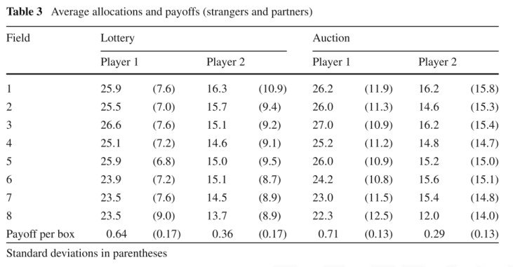

Рисунок 3

## Результаты

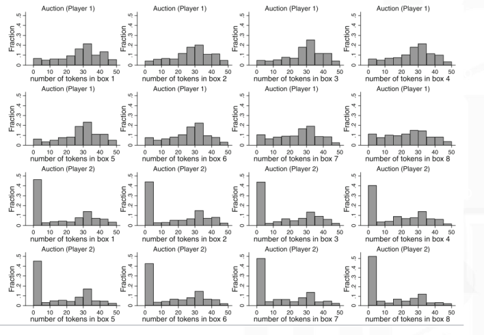

Рисунок 4